# Grafik Interaktif

Muhammad Aswan Syahputra

Selain membuat grafik statis dan animasi dari grafik statis, Anda juga dapat membuat grafik interaktif dengan mudah menggunakan bantuan dari paket plotly. Aktifkanlah paket plotly beserta paket tidyverse dengan cara mengisi bagian ___ dengan jawaban yang tepat!

```r
library(plotly)
library(tidyverse)
```

Sekarang kita Akan melakukan eksperimen dengan menggunakan dataset airquality yang disediakan oleh R. Anda dapat mempelajari informasi dataset ini dengan cara menjalankan `?airquality`. Tulis dan jalankanlah baris kode R untuk mengetahui struktur dataset airquality tersebut!

```r
structure(airquality)
```

```
##     Ozone Solar.R Wind Temp Month Day
## 1      41     190  7.4   67     5   1
## 2      36     118  8.0   72     5   2
## 3      12     149 12.6   74     5   3
## 4      18     313 11.5   62     5   4
## 5      NA      NA 14.3   56     5   5
## 6      28      NA 14.9   66     5   6
## 7      23     299  8.6   65     5   7
## 8      19      99 13.8   59     5   8
## 9       8      19 20.1   61     5   9
## 10     NA     194  8.6   69     5  10
## 11      7      NA  6.9   74     5  11
## 12     16     256  9.7   69     5  12
## 13     11     290  9.2   66     5  13
## 14     14     274 10.9   68     5  14
```

[output cut: 139 more lines]

Jika diperhatikan, penulisan data bulan pada dataset airquality masih menggunakan angka. Dalam *chunk* berikut kita akan mengubah penulisan tersebut menggunakan singkatan nama bulan dan menyimpan hasil perubahan dataset tersebut ke dalam obyek R dengan nama aq. R telah menyediakan vektor yang berisi nama-nama bulan, baik tanpa disingkat dan disingkat, sehingga dapat mudah kita gunakan. Anda dapat mencobanya dengan menjalankan `month.name` dan `month.abb` pada konsol RStudio!

```r
aq <-
  airquality %>%
  mutate(Month = month.abb[.$Month])
aq
```

```
##     Ozone Solar.R Wind Temp Month Day
## 1      41     190  7.4   67   May   1
## 2      36     118  8.0   72   May   2
## 3      12     149 12.6   74   May   3
## 4      18     313 11.5   62   May   4
## 5      NA      NA 14.3   56   May   5
## 6      28      NA 14.9   66   May   6
## 7      23     299  8.6   65   May   7
## 8      19      99 13.8   59   May   8
## 9       8      19 20.1   61   May   9
## 10     NA     194  8.6   69   May  10
## 11      7      NA  6.9   74   May  11
## 12     16     256  9.7   69   May  12
## 13     11     290  9.2   66   May  13
## 14     14     274 10.9   68   May  14
```

[output cut: 139 more lines]

Sekarang buatlah *scatterplot* dengan nama plot_aq berdasarkan kriteria berikut:

- Sumbu x: Solar.R
- Sumbu y: Temp
- *Aesthetic mapping colour*: Month

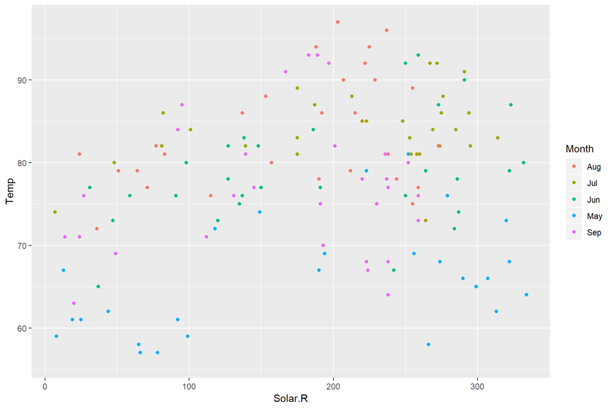

```r
plot_aq <-
  ggplot(aq, aes(x = Solar.R, y = Temp, col = Month)) +
  geom_point()
plot_aq
```

Anda telah membuat *scatterplot* statis dengan nama plot_aq. Sekarang kita akan menggunakan fungsi `ggplotly()` dari paket plotly untuk mengubah grafik statis tersebut menjadi grafik interaktif. Isilah bagian ___ dengan nama *scatterplot* yang telah Anda buat!

```r
iplot_aq <- ggplotly(plot_aq)
iplot_aq
```

[interactive chart not shown]

```r
load("../data/weather.rda")
weather
```

```
## # A tibble: 476 x 5
##    location time                temperature pressure windspeed
##    <chr>    <dttm>                    <dbl>    <dbl>     <dbl>
##  1 Lembang  2015-01-04 07:00:00        20.7    1011.     0.774
##  2 Lembang  2015-01-04 08:00:00        17.5    1013.     4.49
##  3 Lembang  2015-01-04 09:00:00        18.1    1012.     6.63
##  4 Lembang  2015-01-04 10:00:00        17.5    1012.     9.62
##  5 Lembang  2015-01-04 11:00:00        18.8    1011.    10.1
##  6 Lembang  2015-01-04 12:00:00        19.2    1011.     8.71
##  7 Lembang  2015-01-04 13:00:00        19.3    1011.     8.37
##  8 Lembang  2015-01-04 14:00:00        19.1    1011.     7.79
##  9 Lembang  2015-01-04 15:00:00        19.6    1011.     9.34
## 10 Lembang  2015-01-04 16:00:00        19.2    1011.     7.76
## # ... with 466 more rows
```

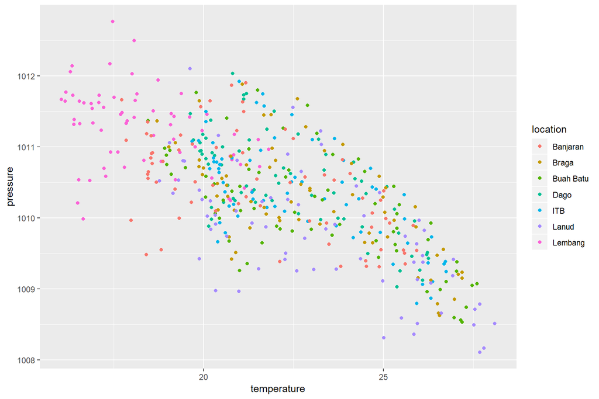

```r
plot_myweather <-
  ggplot(weather, aes(x = temperature, y = pressure, col = location)) +
  geom_point()
plot_myweather
```

1. Menjalankan `iplot_aq` pada RStudio konsol yang otomatis akan membuka *web-viewer*. Kemudian Anda dapat klik pada tombol **Export** pad pilih **Save as Web Page…**
2. Menggunakan fungsi `saveWidget()` dari paket htmlwidgets seperti contoh berikut:

```r
library(htmlwidgets)
saveWidget(iplot_aq, "iplot_aq.html")
```

```r
saveWidget(iplot_aq, "iplot_aq.html")
```

Grafik interaktif sangat cocok disajikan dalam bentuk laman web atau aplikasi web. Anda dapat dengan mudah membuat aplikasi web menggunakan R dengan bantuan paket shiny. Di aplikasi web Anda juga memberikan kontrol kepada pengguna untuk memodifikasi elemen pada grafik statis maupun dinamis. Pada modul 007 Anda ditunjukan cara membuat aplikasi web sederhana dengan hanya menggunakan dokumen R Markdown!